# Final_Maverik_EDA_v3

## **Exploratory Data Analysis: Maverik**

### **Team: Here for the Cinnabon**

Pablo Zarate  
Roman Brock  
Bhoomika John Pedely  
Biva Sherchan

> Introduction

> Data Cleaning

> Data Summaries

> > Data Description

> > Sales by Site IDs

> > Sales Over Time

> > Sales by Holidays

> > Food Service Sales by Categorical Variables

> > > Food Service Sales by Stores that sell Cinnabon

> > > Food Service Sales by Stores that sell lotteries

> > > Food Service Sales by Stores that sell F'Real

> > > Food Service Sales by Stores that sell Bonfire Grill

> > > Food Service Sales by Stores that sell Pizza

> > > Food Service Sales by Stores that have RV Lanes

> > Correlations

> > > Correlations between the 4 sales metrics

> > > Each sales metric with its 7 strongest correlations

> Results

> Contributions

# Introduction

**Business Problem**

Maverik needs an accurate daily forecast of sales KPIs for a new store's first year of sales. Achieving this allows for more effective financial planning and accurate ROI documents. This is a supervised regression problem where the predictors involve both categorical and numerical variables and the targets are four sales metrics.

In order to solve this problem, we will be conducting exploratory data analysis, training a prediction model and providing sales predictions for a new store using the model.

This notebook is the Exploratory Data Analysis portion of our project. We have created a list of questions that will guide our analysis of these datasets:

1. On average, which stores are producing the highest total sales metrics?
2. Describe the datasets.
3. What are sales trends over time? (by month, by week, by day of week, and by holidays)
4. Which variables have the highest correlation with sales?
5. Are the sales metrics correlated with each other?
6. Are there any variables in the datasets that we will not need for our model?
7. Are there any outliers?
8. Do we have any data imbalances?

# Data Cleaning

```python
#Installing Dependencies
import pandas as pd
import numpy as np
import matplotlib.pyplot as plt
import seaborn as sns
import datetime
from pandas.plotting import scatter_matrix
```

```python
import warnings
warnings.filterwarnings('ignore')
```

```python
#Loading data
from google.colab import files
uploaded = files.upload()
```

Upload widget is only available when the cell has been executed in the current browser session. Please rerun this cell to enable.

```
Saving qualitative_data_msba.csv to qualitative_data_msba.csv
Saving time_series_data_msba.csv to time_series_data_msba.csv
```

```python
data_sales = pd.read_csv('time_series_data_msba.csv')
data_stores = pd.read_csv('qualitative_data_msba.csv')
```

```python
#Viewing the data
data_sales
```

|  | Unnamed: 0 | capital_projects.soft_opening_date | calendar.calendar_day_date | calendar.fiscal_week_id_for_year | calendar.day_of_week | calendar_information.holiday | calendar_information.type_of_day | daily_yoy_ndt.total_inside_sales | daily_yoy_ndt.total_food_service | diesel | unleaded | site_id_msba |
| --- | --- | --- | --- | --- | --- | --- | --- | --- | --- | --- | --- | --- |
| 0 | 1 | 2022-06-14 | 2022-06-17 | 25 | Friday | NONE | WEEKDAY | 2168.2920 | 861.6930 | 722.7745 | 1425.1020 | 24535 |
| 1 | 2 | 2022-06-14 | 2022-06-22 | 25 | Wednesday | NONE | WEEKDAY | 2051.5635 | 808.0275 | 730.4850 | 1436.2740 | 24535 |
| 2 | 3 | 2022-06-14 | 2022-06-23 | 25 | Thursday | NONE | WEEKDAY | 2257.5000 | 966.4410 | 895.7970 | 1594.3725 | 24535 |
| 3 | 4 | 2022-06-14 | 2022-06-26 | 26 | Sunday | NONE | WEEKEND | 1520.5925 | 542.3250 | 584.2900 | 1124.9280 | 24535 |
| 4 | 5 | 2022-06-14 | 2022-06-27 | 26 | Monday | NONE | WEEKDAY | 1897.6930 | 771.4525 | 852.2605 | 1640.2540 | 24535 |
| ... | ... | ... | ... | ... | ... | ... | ... | ... | ... | ... | ... | ... |
| 13903 | 13904 | 2021-01-12 | 2021-12-28 | 52 | Tuesday | NONE | WEEKDAY | 2984.0300 | 864.2795 | 1609.7830 | 2492.5180 | 21560 |
| 13904 | 13905 | 2021-01-12 | 2022-01-01 | 1 | Saturday | New Year's Day | WEEKEND | 2483.4145 | 597.8315 | 731.2935 | 1564.0170 | 21560 |
| 13905 | 13906 | 2021-01-12 | 2022-01-04 | 1 | Tuesday | NONE | WEEKDAY | 3169.6875 | 970.4100 | 1851.6470 | 2767.5970 | 21560 |
| 13906 | 13907 | 2021-01-12 | 2022-01-07 | 2 | Friday | NONE | WEEKDAY | 3559.5805 | 1072.4175 | 2104.9070 | 2868.2325 | 21560 |
| 13907 | 13908 | 2021-01-12 | 2022-01-11 | 2 | Tuesday | NONE | WEEKDAY | 3285.5305 | 1061.8510 | 2337.6045 | 2514.3580 | 21560 |

13908 rows × 12 columns

```python
data_stores
```

|  | Unnamed: 0 | open_year | square_feet | front_door_count | years_since_last_project | parking_spaces | lottery | freal | bonfire_grill | pizza | ... | rv_lanes_fueling_positions_2 | hi_flow_rv_lanes_layout | hi_flow_rv_lanes_stack_type | non_24_hour | self_check_out | mens_toilet_count | mens_urinal_count | womens_toilet_count | womens_sink_count | site_id_msba |
| --- | --- | --- | --- | --- | --- | --- | --- | --- | --- | --- | --- | --- | --- | --- | --- | --- | --- | --- | --- | --- | --- |
| 0 | 1 | 2021 | 5046 | 2 | 2 | 38 | Yes | Yes | Yes | No | ... | 6 | Stack | HF/RV | No | Yes | 2 | 2 | 6 | 2 | 21560 |
| 1 | 2 | 2021 | 5046 | 2 | 2 | 39 | No | Yes | Yes | Yes | ... | 4 | Combo | HF/RV | No | Yes | 5 | 5 | 10 | 4 | 21980 |
| 2 | 3 | 2021 | 5046 | 2 | 2 | 35 | Yes | Yes | Yes | Yes | ... | 5 | In-Line | None | No | Yes | 3 | 2 | 4 | 1 | 22015 |
| 3 | 4 | 2021 | 5046 | 2 | 2 | 36 | No | Yes | Yes | Yes | ... | 4 | Combo | HF/RV | No | Yes | 3 | 3 | 6 | 2 | 22085 |
| 4 | 5 | 2021 | 5046 | 2 | 2 | 25 | Yes | Yes | Yes | No | ... | 0 | NaN | NaN | No | Yes | 0 | 0 | 0 | 0 | 22120 |
| 5 | 6 | 2021 | 5046 | 2 | 2 | 38 | Yes | Yes | No | No | ... | 0 | NaN | NaN | No | Yes | 4 | 2 | 4 | 2 | 22260 |
| 6 | 7 | 2021 | 5046 | 2 | 2 | 36 | Yes | Yes | No | No | ... | 4 | Combo | HF/RV | No | Yes | 3 | 3 | 6 | 2 | 22330 |
| 7 | 8 | 2021 | 5046 | 2 | 1 | 38 | Yes | Yes | Yes | No | ... | 4 | Combo | HF/RV | No | Yes | 3 | 3 | 6 | 2 | 22400 |
| 8 | 9 | 2021 | 5046 | 2 | 2 | 41 | Yes | Yes | No | No | ... | 0 | NaN | NaN | No | Yes | 2 | 2 | 4 | 1 | 22505 |
| 9 | 10 | 2021 | 5046 | 2 | 2 | 39 | No | Yes | Yes | Yes | ... | 4 | Combo | HF/RV | No | Yes | 3 | 3 | 6 | 2 | 22540 |
| 10 | 11 | 2021 | 5046 | 2 | 2 | 44 | Yes | Yes | No | Yes | ... | 4 | Combo | HF/RV | No | Yes | 3 | 3 | 6 | 2 | 22575 |
| 11 | 12 | 2021 | 5046 | 2 | 2 | 40 | Yes | Yes | Yes | No | ... | 0 | NaN | NaN | No | Yes | 1 | 3 | 4 | 1 | 22645 |
| 12 | 13 | 2022 | 5046 | 2 | 1 | 35 | No | Yes | Yes | No | ... | 0 | NaN | NaN | No | Yes | 2 | 2 | 4 | 1 | 22680 |
| 13 | 14 | 2021 | 5046 | 2 | 2 | 46 | Yes | Yes | Yes | Yes | ... | 4 | Combo | HF/RV | No | Yes | 3 | 3 | 5 | 2 | 22715 |
| 14 | 15 | 2021 | 5046 | 2 | 2 | 34 | No | Yes | Yes | Yes | ... | 4 | Combo | HF/RV | No | Yes | 2 | 2 | 4 | 1 | 22750 |
| 15 | 16 | 2021 | 5046 | 2 | 2 | 41 | Yes | Yes | Yes | No | ... | 4 | Combo | HF/RV | No | Yes | 3 | 3 | 6 | 2 | 22785 |
| 16 | 17 | 2021 | 5046 | 2 | 2 | 36 | Yes | No | Yes | Yes | ... | 4 | Combo | HF/RV | No | Yes | 2 | 2 | 4 | 1 | 22820 |
| 17 | 18 | 2021 | 5046 | 2 | 2 | 35 | Yes | Yes | Yes | No | ... | 0 | NaN | NaN | No | Yes | 2 | 2 | 4 | 1 | 22855 |
| 18 | 19 | 2022 | 6134 | 2 | 1 | 48 | Yes | Yes | Yes | No | ... | 4 | Combo | HF/RV | No | Yes | 3 | 3 | 2 | 2 | 22890 |
| 19 | 20 | 2021 | 5046 | 2 | 2 | 45 | Yes | Yes | No | No | ... | 0 | NaN | NaN | No | Yes | 2 | 2 | 4 | 1 | 22925 |
| 20 | 21 | 2021 | 5046 | 2 | 2 | 33 | Yes | Yes | No | No | ... | 0 | NaN | NaN | No | Yes | 2 | 2 | 5 | 1 | 23135 |
| 21 | 22 | 2021 | 5046 | 2 | 2 | 41 | Yes | Yes | Yes | Yes | ... | 4 | Combo | HF/RV | No | Yes | 3 | 3 | 6 | 2 | 23240 |
| 22 | 23 | 2021 | 5046 | 2 | 2 | 29 | Yes | Yes | Yes | Yes | ... | 2 | Combo | HF/RV | No | Yes | 2 | 2 | 4 | 1 | 23345 |
| 23 | 24 | 2021 | 5046 | 2 | 2 | 34 | No | Yes | Yes | Yes | ... | 4 | Combo | HF/RV | No | Yes | 3 | 3 | 6 | 2 | 23380 |
| 24 | 25 | 2022 | 2940 | 2 | 1 | 23 | No | Yes | Yes | Yes | ... | 4 | Combo | HF/RV | No | Yes | 2 | 2 | 6 | 3 | 23415 |
| 25 | 26 | 2021 | 5046 | 2 | 2 | 40 | No | Yes | No | No | ... | 0 | NaN | NaN | No | Yes | 2 | 2 | 4 | 1 | 23450 |
| 26 | 27 | 2021 | 5046 | 2 | 2 | 38 | Yes | Yes | No | No | ... | 0 | NaN | NaN | No | Yes | 2 | 2 | 6 | 3 | 23485 |
| 27 | 28 | 2022 | 4600 | 2 | 1 | 34 | Yes | Yes | Yes | No | ... | 0 | NaN | NaN | No | Yes | 1 | 1 | 4 | 2 | 23555 |
| 28 | 29 | 2022 | 5046 | 2 | 1 | 28 | No | Yes | Yes | Yes | ... | 4 | Combo | HF/RV | No | Yes | 3 | 3 | 6 | 2 | 23660 |
| 29 | 30 | 2021 | 5046 | 2 | 2 | 37 | No | Yes | Yes | Yes | ... | 4 | Combo | HF/RV | No | Yes | 3 | 3 | 6 | 2 | 23730 |
| 30 | 31 | 2022 | 5518 | 2 | 1 | 32 | Yes | Yes | Yes | No | ... | 4 | Combo | HF/RV | No | Yes | 2 | 2 | 4 | 1 | 23765 |
| 31 | 32 | 2022 | 5046 | 2 | 1 | 43 | No | Yes | No | No | ... | 4 | Combo | HF/RV | No | Yes | 3 | 3 | 6 | 2 | 23835 |
| 32 | 33 | 2022 | 5518 | 2 | 1 | 39 | No | Yes | No | No | ... | 0 | NaN | NaN | No | Yes | 2 | 2 | 4 | 1 | 23905 |
| 33 | 34 | 2022 | 2933 | 2 | 1 | 30 | Yes | Yes | Yes | No | ... | 0 | NaN | NaN | No | Yes | 2 | 2 | 2 | 2 | 24150 |
| 34 | 35 | 2022 | 4388 | 2 | 1 | 40 | No | Yes | Yes | No | ... | 0 | NaN | NaN | No | Yes | 1 | 1 | 4 | 2 | 24220 |
| 35 | 36 | 2022 | 5951 | 2 | 1 | 49 | No | Yes | Yes | Yes | ... | 4 | Combo | HF/RV | No | Yes | 3 | 3 | 2 | 2 | 24255 |
| 36 | 37 | 2022 | 4630 | 2 | 1 | 45 | Yes | Yes | No | No | ... | 4 | Combo | HF/RV | No | Yes | 1 | 1 | 2 | 2 | 24535 |

37 rows × 55 columns

```python
df = data_stores.merge(data_sales, how = 'inner', on=['site_id_msba'])
pd.set_option('display.max_columns', None)
df.head()
```

|  | Unnamed: 0_x | open_year | square_feet | front_door_count | years_since_last_project | parking_spaces | lottery | freal | bonfire_grill | pizza | cinnabon | godfather_s_pizza | ethanol_free | diesel_x | hi_flow_lanes | rv_lanes | hi_flow_rv_lanes | def | cat_scales | car_wash | ev_charging | rv_dumps | propane | x1_mile_pop | x1_mile_emp | x1_mile_income | x1_2_mile_pop | x1_2_mile_emp | x1_2_mile_income | … |
| --- | --- | --- | --- | --- | --- | --- | --- | --- | --- | --- | --- | --- | --- | --- | --- | --- | --- | --- | --- | --- | --- | --- | --- | --- | --- | --- | --- | --- | --- | --- |
| 0 | 1 | 2021 | 5046 | 2 | 2 | 38 | Yes | Yes | Yes | No | No | No | Yes | Yes | Yes | Yes | Yes | Yes | No | No | No | Yes | Yes | 4046 | 3648 | 43435 | 556 | 642 | 45678 | … |
| 1 | 1 | 2021 | 5046 | 2 | 2 | 38 | Yes | Yes | Yes | No | No | No | Yes | Yes | Yes | Yes | Yes | Yes | No | No | No | Yes | Yes | 4046 | 3648 | 43435 | 556 | 642 | 45678 | … |
| 2 | 1 | 2021 | 5046 | 2 | 2 | 38 | Yes | Yes | Yes | No | No | No | Yes | Yes | Yes | Yes | Yes | Yes | No | No | No | Yes | Yes | 4046 | 3648 | 43435 | 556 | 642 | 45678 | … |
| 3 | 1 | 2021 | 5046 | 2 | 2 | 38 | Yes | Yes | Yes | No | No | No | Yes | Yes | Yes | Yes | Yes | Yes | No | No | No | Yes | Yes | 4046 | 3648 | 43435 | 556 | 642 | 45678 | … |
| 4 | 1 | 2021 | 5046 | 2 | 2 | 38 | Yes | Yes | Yes | No | No | No | Yes | Yes | Yes | Yes | Yes | Yes | No | No | No | Yes | Yes | 4046 | 3648 | 43435 | 556 | 642 | 45678 | … |

```python
df.shape
```

```
(13542, 66)
```

```python
df.info()
```

```
<class 'pandas.core.frame.DataFrame'>
Int64Index: 13542 entries, 0 to 13541
Data columns (total 66 columns):
 #   Column                                   Non-Null Count  Dtype
---  ------                                   --------------  -----
 0   Unnamed: 0_x                             13542 non-null  int64
 1   open_year                                13542 non-null  int64
 2   square_feet                              13542 non-null  int64
 3   front_door_count                         13542 non-null  int64
 4   years_since_last_project                 13542 non-null  int64
 5   parking_spaces                           13542 non-null  int64
 6   lottery                                  13542 non-null  object
 7   freal                                    13542 non-null  object
 8   bonfire_grill                            13542 non-null  object
 9   pizza                                    13542 non-null  object
```

[output cut: 58 more lines]

```python
df = df.drop(['Unnamed: 0_x','Unnamed: 0_y'], axis = 1)
```

```python
#Replacing nulls with None
cols_to_none = ['rv_lanes_layout','rv_lanes_stack_type','hi_flow_lanes_layout','hi_flow_lanes_stack_type','hi_flow_rv_lanes_layout','hi_flow_rv_lanes_stack_type']
for col_name in cols_to_none:
    df[col_name].fillna("None", inplace=True)
```

```python
df['capital_projects.soft_opening_date'] = pd.to_datetime(df['capital_projects.soft_opening_date'])
df['calendar.calendar_day_date'] = pd.to_datetime(df['calendar.calendar_day_date'])
```

```python
#Adding a month column
df['calendar.month'] = pd.DatetimeIndex(df['calendar.calendar_day_date']).month
```

```python
df.info()
```

```
<class 'pandas.core.frame.DataFrame'>
Int64Index: 13542 entries, 0 to 13541
Data columns (total 65 columns):
 #   Column                                   Non-Null Count  Dtype
---  ------                                   --------------  -----
 0   open_year                                13542 non-null  int64
 1   square_feet                              13542 non-null  int64
 2   front_door_count                         13542 non-null  int64
 3   years_since_last_project                 13542 non-null  int64
 4   parking_spaces                           13542 non-null  int64
 5   lottery                                  13542 non-null  object
 6   freal                                    13542 non-null  object
 7   bonfire_grill                            13542 non-null  object
 8   pizza                                    13542 non-null  object
 9   cinnabon                                 13542 non-null  object
```

[output cut: 57 more lines]

# Data Summaries

## Data Description

```python
df.describe()
```

|  | open_year | square_feet | front_door_count | years_since_last_project | parking_spaces | x1_mile_pop | x1_mile_emp | x1_mile_income | x1_2_mile_pop | x1_2_mile_emp | x1_2_mile_income | x5_min_pop | x5_min_emp | x5_min_inc | x7_min_pop | x7_min_emp | x7_min_inc | traditional_forecourt_fueling_positions | rv_lanes_fueling_positions | hi_flow_lanes_fueling_positions | hi_flow_lanes_fueling_positions_2 | rv_lanes_fueling_positions_2 | mens_toilet_count | mens_urinal_count | womens_toilet_count | womens_sink_count | site_id_msba | calendar.fiscal_week_id_for_year | daily_yoy_ndt.total_inside_sales | … |
| --- | --- | --- | --- | --- | --- | --- | --- | --- | --- | --- | --- | --- | --- | --- | --- | --- | --- | --- | --- | --- | --- | --- | --- | --- | --- | --- | --- | --- | --- | --- |
| count | 13542.000000 | 13542.000000 | 13542.0 | 13542.000000 | 13542.000000 | 13542.000000 | 13542.000000 | 13542.000000 | 13542.000000 | 13542.000000 | 13542.000000 | 13542.000000 | 13542.000000 | 13542.000000 | 13542.000000 | 13542.000000 | 13542.000000 | 13542.000000 | 13542.000000 | 13542.000000 | 13542.000000 | 13542.000000 | 13542.000000 | 13542.000000 | 13542.000000 | 13542.000000 | 13542.000000 | 13542.000000 | 13542.000000 | … |
| mean | 2021.324324 | 4970.270270 | 2.0 | 1.648649 | 37.405405 | 6703.567568 | 4757.648649 | 53300.378378 | 1833.108108 | 1514.135135 | 47012.405405 | 14528.702703 | 9121.972973 | 55292.135135 | 32303.621622 | 19224.054054 | 59849.837838 | 14.270270 | 2.513514 | 3.324324 | 3.324324 | 2.513514 | 2.378378 | 2.351351 | 4.648649 | 1.702703 | 23040.405405 | 26.497637 | 2853.020648 | … |
| std | 0.468139 | 568.116022 | 0.0 | 0.477410 | 5.837928 | 5616.745584 | 4633.429341 | 24002.836485 | 1889.152682 | 2455.642483 | 27710.571374 | 13237.350698 | 8539.761593 | 24041.455659 | 30455.849984 | 20199.260887 | 18710.108775 | 3.895038 | 2.021870 | 2.885803 | 2.885803 | 2.021870 | 0.910969 | 0.845247 | 1.727681 | 0.730257 | 720.163006 | 14.996845 | 988.392541 | … |
| min | 2021.000000 | 2933.000000 | 2.0 | 1.000000 | 23.000000 | 0.000000 | 56.000000 | 0.000000 | 0.000000 | 31.000000 | 0.000000 | 0.000000 | 456.000000 | 0.000000 | 688.000000 | 615.000000 | 31540.000000 | 10.000000 | 0.000000 | 0.000000 | 0.000000 | 0.000000 | 0.000000 | 0.000000 | 0.000000 | 0.000000 | 21560.000000 | 1.000000 | 0.000000 | … |
| 25% | 2021.000000 | 5046.000000 | 2.0 | 1.000000 | 34.000000 | 1984.000000 | 1771.000000 | 39538.000000 | 262.000000 | 386.000000 | 28185.000000 | 4725.000000 | 3131.000000 | 41009.000000 | 10672.000000 | 6870.000000 | 48170.000000 | 12.000000 | 0.000000 | 0.000000 | 0.000000 | 0.000000 | 2.000000 | 2.000000 | 4.000000 | 1.000000 | 22540.000000 | 14.000000 | 2182.879125 | … |
| 50% | 2021.000000 | 5046.000000 | 2.0 | 2.000000 | 38.000000 | 5574.000000 | 3895.000000 | 46356.000000 | 1003.000000 | 1037.000000 | 44706.000000 | 12789.000000 | 6348.000000 | 50232.000000 | 24597.000000 | 11584.000000 | 53805.000000 | 12.000000 | 4.000000 | 5.000000 | 5.000000 | 4.000000 | 2.000000 | 2.000000 | 4.000000 | 2.000000 | 22890.000000 | 26.000000 | 2694.347250 | … |
| 75% | 2022.000000 | 5046.000000 | 2.0 | 2.000000 | 41.000000 | 11269.000000 | 6002.000000 | 73519.000000 | 2686.000000 | 1616.000000 | 69253.000000 | 20792.000000 | 11479.000000 | 74911.000000 | 44247.000000 | 26238.000000 | 77818.000000 | 16.000000 | 4.000000 | 5.000000 | 5.000000 | 4.000000 | 3.000000 | 3.000000 | 6.000000 | 2.000000 | 23555.000000 | 39.000000 | 3337.182625 | … |
| max | 2022.000000 | 6134.000000 | 2.0 | 2.000000 | 49.000000 | 18692.000000 | 26077.000000 | 110957.000000 | 5923.000000 | 15403.000000 | 104730.000000 | 55385.000000 | 34199.000000 | 114281.000000 | 137979.000000 | 83985.000000 | 108534.000000 | 24.000000 | 6.000000 | 9.000000 | 9.000000 | 6.000000 | 5.000000 | 5.000000 | 10.000000 | 4.000000 | 24535.000000 | 52.000000 | 7172.466000 | … |

There are 37 stores with various qualitative factors that may impact sales metrics. Time series data includes date range 1/12/2021 - 8/16/2023.

## Sales by Site IDs

```python
sales_by_site = df.groupby('site_id_msba')['daily_yoy_ndt.total_inside_sales','daily_yoy_ndt.total_food_service','diesel_y','unleaded'].sum()
sales_by_site
```

| site_id_msba | daily_yoy_ndt.total_inside_sales | daily_yoy_ndt.total_food_service | diesel_y | unleaded |
| --- | --- | --- | --- | --- |
| 21560 | 1.214690e+06 | 354598.8600 | 6.430766e+05 | 9.901373e+05 |
| 21980 | 1.498524e+06 | 502249.9720 | 4.032473e+06 | 9.858105e+05 |
| 22015 | 1.161861e+06 | 261373.8330 | 2.327281e+05 | 9.839800e+05 |
| 22085 | 1.760452e+06 | 562647.1340 | 6.838006e+05 | 7.586291e+05 |
| 22120 | 7.936885e+05 | 202863.4370 | 1.836461e+05 | 1.207583e+06 |
| 22260 | 1.042695e+06 | 169516.8545 | 1.816719e+05 | 1.871780e+06 |
| 22330 | 9.677165e+05 | 240998.1315 | 6.929393e+05 | 5.750155e+05 |
| 22400 | 9.137954e+05 | 264761.1855 | 5.596750e+05 | 9.762767e+05 |
| 22505 | 7.671938e+05 | 150780.0665 | 6.011251e+04 | 5.526987e+05 |
| 22540 | 1.087628e+06 | 303471.4060 | 7.158180e+05 | 9.733434e+05 |
| 22575 | 7.161628e+05 | 217969.8535 | 6.270690e+05 | 1.247385e+06 |
| 22645 | 7.773472e+05 | 145938.3905 | 1.105079e+05 | 1.376313e+06 |
| 22680 | 8.847862e+05 | 195586.8915 | 5.161349e+04 | 3.542089e+05 |
| 22715 | 1.068181e+06 | 278964.9975 | 1.661725e+06 | 8.864797e+05 |
| 22750 | 1.645517e+06 | 411154.4150 | 5.944515e+05 | 7.817609e+05 |
| 22785 | 1.008834e+06 | 308683.4345 | 9.773292e+05 | 7.916598e+05 |
| 22820 | 9.640506e+05 | 271065.1860 | 1.386003e+06 | 7.762061e+05 |
| 22855 | 9.403193e+05 | 225148.8085 | 2.941571e+05 | 9.167156e+05 |
| 22890 | 8.238563e+05 | 296735.2465 | 1.197417e+06 | 7.764653e+05 |
| 22925 | 1.035184e+06 | 216371.7605 | 7.064658e+04 | 6.734016e+05 |
| 23135 | 7.777817e+05 | 164968.9335 | 9.550326e+04 | 5.114670e+05 |
| 23240 | 1.038296e+06 | 294620.4135 | 7.287774e+05 | 1.024587e+06 |
| 23345 | 1.307856e+06 | 355186.3280 | 2.076396e+05 | 6.421107e+05 |
| 23380 | 1.185018e+06 | 357002.6285 | 7.764618e+05 | 1.060127e+06 |
| 23415 | 1.375429e+06 | 429074.6705 | 9.056087e+05 | 6.357568e+05 |
| 23450 | 9.484174e+05 | 208904.9515 | 1.842829e+05 | 7.194501e+05 |
| 23485 | 6.938792e+05 | 178577.4060 | 1.861335e+05 | 1.406596e+06 |
| 23555 | 8.144809e+05 | 192470.1135 | 7.708222e+04 | 7.365636e+05 |
| 23660 | 1.301624e+06 | 363344.4920 | 1.161382e+06 | 1.298770e+06 |
| 23730 | 1.224231e+06 | 309688.5855 | 6.540643e+05 | 6.276098e+05 |
| 23765 | 1.039964e+06 | 335804.8540 | 4.747657e+05 | 8.472020e+05 |
| 23835 | 9.341134e+05 | 233393.6780 | 9.589193e+05 | 7.695884e+05 |
| 23905 | 7.968196e+05 | 228232.1755 | 9.744941e+04 | 5.003502e+05 |
| 24150 | 1.208365e+06 | 289678.8965 | 4.227108e+05 | 1.215525e+06 |
| 24220 | 1.003232e+06 | 239198.3230 | 6.320836e+04 | 3.809128e+05 |
| 24255 | 8.194048e+05 | 270409.8285 | 1.097132e+06 | 4.801674e+05 |
| 24535 | 1.094213e+06 | 350993.7165 | 4.978565e+05 | 1.046078e+06 |

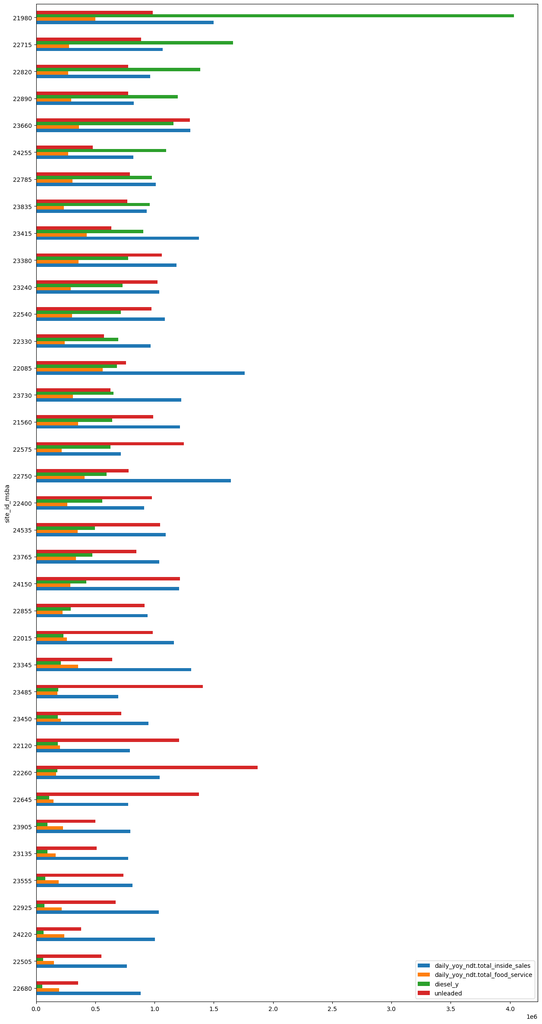

```python
sales_by_site.sort_values(by = 'diesel_y', ascending = True).plot(kind='barh', figsize = (15,30))
#Check out store 21980
```

Store 21980 is showing extremely high diesel sales relative to other stores. What is the reasoning for this high sales volume?

We also see that store 22260 has the highest unleaded sales and store 22085 has the highest inside sales.

Interestingly, food services sales is very low for all stores relative to other sales metrics.

## Sales Over Time

```python
sales_by_date = df.groupby('calendar.calendar_day_date')['daily_yoy_ndt.total_inside_sales','daily_yoy_ndt.total_food_service','diesel_y','unleaded'].mean()
sales_by_date
```

| calendar.calendar_day_date | daily_yoy_ndt.total_inside_sales | daily_yoy_ndt.total_food_service | diesel_y | unleaded |
| --- | --- | --- | --- | --- |
| 2021-01-12 | 2036.2685 | 762.8530 | 1424.1850 | 1522.0030 |
| 2021-01-13 | 2379.8880 | 1003.7930 | 1303.8445 | 1853.7715 |
| 2021-01-14 | 2435.8600 | 974.2250 | 1375.6785 | 2122.4070 |
| 2021-01-15 | 2805.9780 | 911.0115 | 1334.9175 | 2267.9930 |
| 2021-01-16 | 2314.7635 | 715.7535 | 831.1625 | 1819.6395 |
| ... | ... | ... | ... | ... |
| 2023-08-12 | 4160.1840 | 843.5980 | 775.0610 | 3625.6535 |
| 2023-08-13 | 3378.9595 | 719.3655 | 1054.0110 | 3385.9315 |
| 2023-08-14 | 3156.0760 | 772.2015 | 970.6655 | 3203.5885 |
| 2023-08-15 | 3331.7060 | 843.6260 | 1066.5375 | 2911.9055 |
| 2023-08-16 | 3389.2145 | 849.2155 | 811.8005 | 3155.2360 |

947 rows × 4 columns

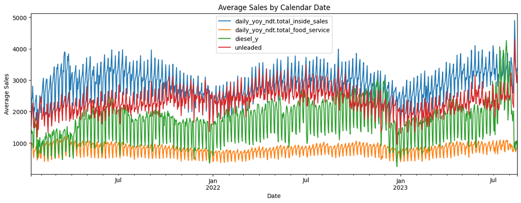

```python
sales_by_date.plot(figsize = (15,5),
                   title = 'Average Sales by Calendar Date',
                   xlabel = 'Date', ylabel = 'Average Sales')
```

The sales by month and sales by week charts below show similar trends.

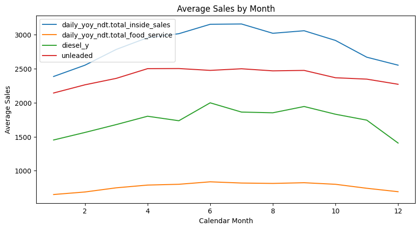

```python
#Sales by month
sales_by_month = df.groupby('calendar.month')['daily_yoy_ndt.total_inside_sales','daily_yoy_ndt.total_food_service','diesel_y','unleaded'].mean()
sales_by_month.plot(figsize = (10,5),
                    title = 'Average Sales by Month',
                    xlabel = 'Calendar Month', ylabel = 'Average Sales' )
```

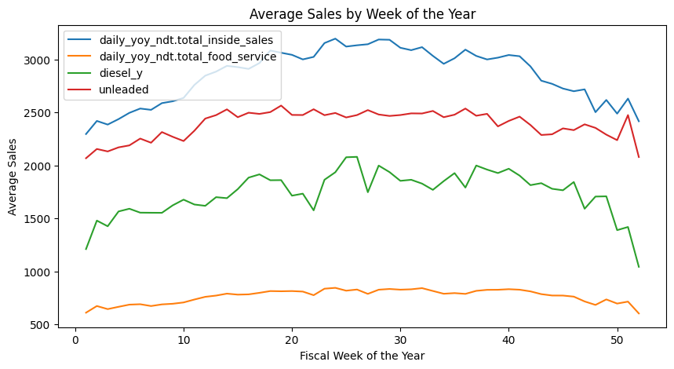

```python
#Sales by week
sales_by_week = df.groupby('calendar.fiscal_week_id_for_year')['daily_yoy_ndt.total_inside_sales','daily_yoy_ndt.total_food_service','diesel_y','unleaded'].mean()
sales_by_week.plot(figsize = (10,5),
                   title = 'Average Sales by Week of the Year',
                   xlabel = 'Fiscal Week of the Year', ylabel = 'Average Sales')
```

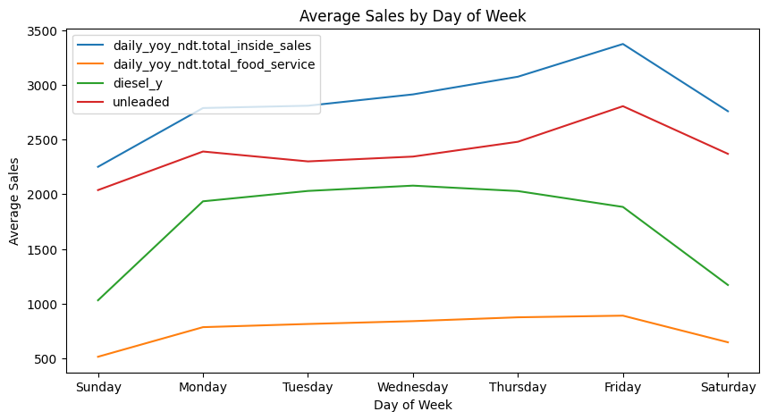

```python
#Sales by day of week
# Define the desired order of the days of the week
desired_order = ['Sunday', 'Monday', 'Tuesday', 'Wednesday', 'Thursday', 'Friday', 'Saturday']

# Reorder the rows based on the desired order
sales_by_dayofweek = df.groupby('calendar.day_of_week')['daily_yoy_ndt.total_inside_sales','daily_yoy_ndt.total_food_service','diesel_y','unleaded'].mean()
sales_by_dayofweek = sales_by_dayofweek.reindex(desired_order)

sales_by_dayofweek.plot(figsize = (10,5),
                        title = 'Average Sales by Day of Week',
                        xlabel = 'Day of Week', ylabel = 'Average Sales')
```

Overall, Maverik experiences higher sales on weekdays compared to weekends. Total inside sales and unleaded sales follow an upward trend throughout the week and peak on Friday. Diesel and food service sales remain steady throughout the weekday.